# A Jump-Start into R for Statistical Programmers and Analysts

10/18/2017

## (Optional) Pre-Webinar Downloads

- If you want to run the commands as I present them, you will need to download R and then RStudio (Both are free.).
- R: Available at the [CRAN site](https://cran.r-project.org/)
- RStudio: Available at [their website](https://www.rstudio.com/products/rstudio/download/#download)
- You will also need to install some packages. Here is the code to do so. Run this code in the console.
  - Note: We will discuss package installation during the talk.

```r
install.packages(c("dplyr", "ggplot2", "data.table", "mosaic", "broom",
    "caret", "readr", "knitr"))
```

- [Materials are on github](https://github.com/mcconvil/jumpstart_R_webinar).

## Components of the Jump-Start

- Introduction to R
- Introduction the RStudio IDE
- Whirlwind tour of data analysis in R
  - Discuss a reproducible workflow.
  - Highlight some of the popular functions and packages.
- Along the way, you will receive loads of links and resources for taking the jump-start to the next level.

## What is not part of the Jump-Start

- Why R is better than package X.
  - Will briefly discuss strengths of R.
    - Want to spend our time learning R rather than talking about why you should learn R!
  - If you are interested in joining the debate, there are plenty of forums and blog posts you can visit.
    - [Like this one.](https://datacamp.wpengine.com/wp-content/uploads/2014/05/infograph.png)
    - [And this one.](http://www.theanalyticslab.nl/2017/03/18/python-r-vs-spss-sas/)
    - [Here's another one.](http://r4stats.com/articles/popularity/)
    - [One on weaknesses of R.](http://r4stats.com/articles/why-r-is-hard-to-learn/)
- Deep conversation about memory, speed, specific configurations, big data, integration with Spark…

## My Background

- R user for 12 years
- How do I use R in my research?
  - Data wrangling
  - Graphing
  - Summarizing
  - Simulations
  - Analyzing
    - Currently writing an R package of model-assisted survey estimators.
  - Writing

## My Background

- Teacher of R for 6 years
- How do I use R in my teaching?
  - To teach the whole data analysis workflow
  - To build intuition about concepts

## Assumptions about the Audience

- A programmer or analyst who is familiar with a different statistical program.
- Have little to no experience with R.
- Have decided it is worthwhile to learn about R.
  - Possibly on the fence as to whether or not to switch to R.

## Strengths of R

- Free and open source
- Platform independent
- Fosters a reproducible workflow
- Active community of users and programmers making R better

## Coupling R with RStudio

- RStudio is an integrated development environment (IDE) for the R statistical language.
- The common analogy:

[figure not shown]

## Coupling R with RStudio

- RStudio is an integrated development environment (IDE) for the R statistical language.
- The common analogy:

[figure not shown]

## Coupling R with RStudio

- Let's acquaint ourselves with the different components of RStudio.

## Highlights of RStudio

- Lower Right:
  - Files, Plots, Packages, Help
- Upper Right:
  - Environment, History
- Lower Left: Console
- Upper Left: Text editor
- Nice Features:
  - Importing Data
  - Tab completion
  - Integration with [github](https://github.com/)
    - [Fabulous guide](http://happygitwithr.com/)

## Getting Help

- If you know the function's exact name:

```r
?lm
```

- If you know specific keywords:

```r
help.search("linear model")
```

- If you have an idea but not the specific word/function, I recommend trying Google or Stack Overflow.

## Resources

- [R FAQ](https://cran.r-project.org/doc/FAQ/R-FAQ.html)
- [DataCamp](https://www.datacamp.com/)
- RStudio:
  - [CheatSheets](https://www.rstudio.com/resources/cheatsheets/)
  - [Online Learning](https://www.rstudio.com/online-learning/)
  - [Webinars](https://www.rstudio.com/resources/webinars/)
- Join a local user group:
  - [R user groups](https://jumpingrivers.github.io/meetingsR/r-user-groups.html)
  - [R Ladies](https://rladies.org/)

## Base R versus the [Tidyverse](https://www.tidyverse.org/)

- **Question**: Should I use a built-in function or a function that exists in a package?
- How do you use a function from an R package?
  - First install the package:

```r
# Only do once
install.packages("mosaic")
```

- Then load the package every time you want to use its functions:

```r
library(mosaic)
favstats(1:10)
```

```
##  min  Q1 median  Q3 max mean sd  n missing
##    1 3.2    5.5 7.8  10  5.5  3 10       0
```

## R Objects: [Data Types](http://www.statmethods.net/input/datatypes.html)

- The common data objects in R are:
  - Vectors: one dimensional array
    - Types: numeric, integer, character, factor, logical
  - Matrices: two dimensional array
    - Each column must have the same type
  - **Data Frames**: two dimensional array
    - Columns may have different types
  - Lists
    - Items don't need to be the same size.

## Read in the data

- Option 1: Use the "Import Dataset" button
- Option 2: Console

```r
# Base R
eruptions <- read.csv("GVP_Eruption_Results.csv")

# Tidyverse
library(readr)
eruptions <- read_csv("GVP_Eruption_Results.csv")

# data.table
library(data.table)
eruptions <- fread("GVP_Eruption_Results.csv")
```

- <- is the "assignment operator".
- The *eruptions* dataset is all documented eruptions and is from the [Smithsonian Institution Global Volcanism Program.](http://volcano.si.edu/)

## Read in the data

- You can read in many different file formats into R!
  - Excel
  - Text file
  - SPSS
  - SAS
  - STATA
  - …

## Read in the data

- Main differences between base, *readr*, and *data.table*:
  - All read a flat file into a data frame.
    - *readr* reads in as a [tibble](https://cran.r-project.org/web/packages/tibble/vignettes/tibble.html).
    - *data.table* reads in as a [data.table](https://www.rdocumentation.org/packages/data.table/versions/1.10.4/topics/data.table-package).
  - readr and data.table don't automatically convert characters to factors.
    - [Why?](https://simplystatistics.org/2015/07/24/stringsasfactors-an-unauthorized-biography/)
  - Time: base > readr > data.table

|  | read.csv | read_csv | fread |
| --- | --- | --- | --- |
| elapsed | 0.1 | 0.04 | 0.02 |

## Data Exploration

```r
# Class
class(eruptions)
```

```
## [1] "data.table" "data.frame"
```

```r
# Convert to a data frame
eruptions <- data.frame(eruptions)
```

```r
View(eruptions)
```

## Data Exploration

```r
# Look at a few observations
head(eruptions)
```

```
##   Volcano_Number           Volcano_Name Eruption_Number  Eruption_Category
## 1         352090                 Sangay           22231 Confirmed Eruption
## 2         264050           Sangeang Api           22228 Confirmed Eruption
## 3         233020 Fournaise, Piton de la           22224 Confirmed Eruption
## 4         263200 Dieng Volcanic Complex           22227 Confirmed Eruption
## 5         252120                 Ulawun           22225 Confirmed Eruption
## 6         273010                Bulusan           22229 Confirmed Eruption
##   Area_of_Activity VEI VEI_Modifier Start_Year_Modifier Start_Year
## 1                   NA                                        2017
## 2                   NA                                        2017
## 3                   NA                                        2017
## 4                   NA                                        2017
## 5                   NA                                        2017
## 6                   NA                                        2017
##   Start_Year_Uncertainty Start_Month Start_Day_Modifier Start_Day
```

[output cut: 27 more lines]

## Data Exploration

```r
names(eruptions)
```

```
##  [1] "Volcano_Number"           "Volcano_Name"
##  [3] "Eruption_Number"          "Eruption_Category"
##  [5] "Area_of_Activity"         "VEI"
##  [7] "VEI_Modifier"             "Start_Year_Modifier"
##  [9] "Start_Year"               "Start_Year_Uncertainty"
## [11] "Start_Month"              "Start_Day_Modifier"
## [13] "Start_Day"                "Start_Day_Uncertainty"
## [15] "Evidence_Method_.dating." "End_Year_Modifier"
## [17] "End_Year"                 "End_Year_Uncertainty"
## [19] "End_Month"                "End_Day_Modifier"
## [21] "End_Day"                  "End_Day_Uncertainty"
## [23] "Latitude"                 "Longitude"
```

```r
dim(eruptions)
```

```
## [1] 11097    24
```

## Data Exploration

```r
str(eruptions)
```

```
## 'data.frame':    11097 obs. of  24 variables:
##  $ Volcano_Number          : int  352090 264050 233020 263200 252120 273010 261140 300130 357090 345020 ...
##  $ Volcano_Name            : chr  "Sangay" "Sangeang Api" "Fournaise, Piton de la" "Dieng Volcanic Complex" ...
##  $ Eruption_Number         : int  22231 22228 22224 22227 22225 22229 22226 22230 22232 22208 ...
##  $ Eruption_Category       : chr  "Confirmed Eruption" "Confirmed Eruption" "Confirmed Eruption" "Confirmed Eruption" ...
##  $ Area_of_Activity        : chr  "" "" "" "" ...
##  $ VEI                     : int  NA NA NA NA NA NA NA NA NA NA ...
##  $ VEI_Modifier            : chr  "" "" "" "" ...
##  $ Start_Year_Modifier     : chr  "" "" "" "" ...
##  $ Start_Year              : int  2017 2017 2017 2017 2017 2017 2017 2017 2017 2017 ...
##  $ Start_Year_Uncertainty  : int  NA NA NA NA NA NA NA NA NA NA ...
##  $ Start_Month             : int  7 7 7 7 6 6 6 6 6 5 ...
##  $ Start_Day_Modifier      : chr  "" "" "" "" ...
##  $ Start_Day               : int  20 15 14 2 11 5 4 4 4 23 ...
##  $ Start_Day_Uncertainty   : int  NA NA NA NA NA NA NA NA NA NA ...
##  $ Evidence_Method_.dating.: chr  "Historical Observations" "Historical Observations" "Historical Observations" "Historical Observations" ...
##  $ End_Year_Modifier       : chr  ">" ">" ">" "" ...
##  $ End_Year                : int  2017 2017 2017 2017 2017 2017 2017 2017 2017 2017 ...
##  $ End_Year_Uncertainty    : int  NA NA NA NA NA NA NA NA NA NA ...
##  $ End_Month               : int  9 7 8 7 8 6 6 8 7 7 ...
##  $ End_Day_Modifier        : chr  "" "" "" "" ...
##  $ End_Day                 : int  8 30 23 2 8 5 4 4 17 5 ...
##  $ End_Day_Uncertainty     : int  NA NA NA NA NA NA NA NA NA NA ...
##  $ Latitude                : num  -2 -8.2 -21.24 -7.2 -5.05 ...
##  $ Longitude               : num  -78.3 119.1 55.7 109.9 151.3 ...
```

## Data Wrangling: Some base R functions

```r
# Subsetting: Select rows
eruptions[1, ]
```

```
##   Volcano_Number Volcano_Name Eruption_Number  Eruption_Category
## 1         352090       Sangay           22231 Confirmed Eruption
##   Area_of_Activity VEI VEI_Modifier Start_Year_Modifier Start_Year
## 1                   NA                                        2017
##   Start_Year_Uncertainty Start_Month Start_Day_Modifier Start_Day
## 1                     NA           7                           20
##   Start_Day_Uncertainty Evidence_Method_.dating. End_Year_Modifier
## 1                    NA  Historical Observations                 >
##   End_Year End_Year_Uncertainty End_Month End_Day_Modifier End_Day
## 1     2017                   NA         9                        8
##   End_Day_Uncertainty Latitude Longitude
## 1                  NA       -2       -78
```

## Data Wrangling: Some base R functions

```r
# Subsetting: Select columns
eruptions[, 2]
```

```
##     [1] "Sangay"
##     [2] "Sangeang Api"
##     [3] "Fournaise, Piton de la"
##     [4] "Dieng Volcanic Complex"
##     [5] "Ulawun"
##     [6] "Bulusan"
##     [7] "Marapi"
##     [8] "Karymsky"
##     [9] "Copahue"
##    [10] "Rincon de la Vieja"
##    [11] "Karangetang"
##    [12] "Nishinoshima"
##    [13] "Poas"
##    [14] "Aira"
##    [15] "Kambalny"
```

[output cut: 11082 more lines]

```r
# 0ther ways of selecting a column
eruptions$Volcano_Name
eruptions[, "Volcano_Name"]
```

## Data Wrangling: Some base R functions

```r
# More subsetting examples
eruptions[1, 2]
```

```
## [1] "Sangay"
```

```r
eruptions[-(2:11097), 2]
```

```
## [1] "Sangay"
```

```r
eruptions[200:202, c(2, 9)]
```

```
##                        Volcano_Name Start_Year
## 200 Etorofu-Yakeyama [Grozny Group]       2012
## 201                    White Island       2012
## 202                       Tongariro       2012
```

## Data Wrangling: Some base R functions

```r
# Subset: select columns
eruptions2 <- eruptions[, c("Eruption_Category", "VEI", "Start_Year", "End_Year")]

# Subset: select rows
eruptions3 <- subset(eruptions2, Eruption_Category == "Confirmed Eruption" &
    Start_Year > 1900)

# Add column which is a function of existing columns
eruptions3$Length <- eruptions3$End_Year - eruptions3$Start_Year
```

## Data Wrangling: Some base R functions

```r
# Arrange by Length
head(eruptions3[order(eruptions3$Length, decreasing = TRUE), ], 10)
```

```
##       Eruption_Category VEI Start_Year End_Year Length
## 3622 Confirmed Eruption   3       1922     2017     95
## 3236 Confirmed Eruption   3       1933     2017     84
## 3212 Confirmed Eruption   2       1934     2017     83
## 3201 Confirmed Eruption   3       1934     2011     77
## 2499 Confirmed Eruption   3       1955     2016     61
## 2043 Confirmed Eruption   0       1967     2017     50
## 3458 Confirmed Eruption   1       1927     1977     50
## 1820 Confirmed Eruption   2       1972     2017     45
## 1992 Confirmed Eruption   3       1968     2010     42
## 2034 Confirmed Eruption   3       1967     2009     42
```

## Data Wrangling: Some base R functions

```r
# Perform operation by specified grouping
length(eruptions3$Eruption_Category)
```

```
## [1] 3691
```

```r
eruptions4 <- aggregate(Eruption_Category ~ Start_Year, data = eruptions3,
    FUN = length)
eruptions4
```

```
##     Start_Year Eruption_Category
## 1         1901                16
## 2         1902                34
## 3         1903                20
## 4         1904                31
## 5         1905                25
## 6         1906                31
## 7         1907                43
## 8         1908                24
## 9         1909                28
## 10        1910                31
## 11        1911                27
## 12        1912                22
## 13        1913                23
## 14        1914                27
```

[output cut: 103 more lines]

## Data Wrangling: Tidyverse with [dplyr](http://dplyr.tidyverse.org/)

```r
library(dplyr)

# Subset: select columns
eruptions2 <- select(eruptions, Eruption_Category, VEI, Start_Year, End_Year)

# Subset: select rows
eruptions3 <- filter(eruptions2, Eruption_Category == "Confirmed Eruption",
    Start_Year > 1900)

# Add column which is a function of existing columns
eruptions4 <- mutate(eruptions3, Length = End_Year - Start_Year)
```

## Data Wrangling: Tidyverse with [dplyr](http://dplyr.tidyverse.org/)

```r
# Arrange by Length
head(arrange(eruptions4, desc(Length)), 10)
```

```
##     Eruption_Category VEI Start_Year End_Year Length
## 1  Confirmed Eruption   3       1922     2017     95
## 2  Confirmed Eruption   3       1933     2017     84
## 3  Confirmed Eruption   2       1934     2017     83
## 4  Confirmed Eruption   3       1934     2011     77
## 5  Confirmed Eruption   3       1955     2016     61
## 6  Confirmed Eruption   0       1967     2017     50
## 7  Confirmed Eruption   1       1927     1977     50
## 8  Confirmed Eruption   2       1972     2017     45
## 9  Confirmed Eruption   3       1968     2010     42
## 10 Confirmed Eruption   3       1967     2009     42
```

## Data Wrangling: Tidyverse with [dplyr](http://dplyr.tidyverse.org/)

```r
# Aggregate by values of a variable
eruptions5 <- group_by(eruptions4, Start_Year)

# Perform operation by specified grouping
eruptions6 <- summarize(eruptions5, count = n(), avg_VEI = mean(VEI, na.rm = TRUE),
    maxLength = max(Length, na.rm = TRUE))
eruptions6
```

```
## # A tibble: 117 x 4
##    Start_Year count avg_VEI maxLength
##         <int> <int>   <dbl>     <dbl>
##  1       1901    16     2.1         0
##  2       1902    34     1.9         3
##  3       1903    20     1.6        10
##  4       1904    31     1.9         2
##  5       1905    25     1.7         6
##  6       1906    31     1.8        18
##  7       1907    43     1.8         3
##  8       1908    24     1.7         6
##  9       1909    28     1.9         5
## 10       1910    31     1.7        21
## # ... with 107 more rows
```

## Data Wrangling: Tidyverse with dplyr and [magrittr](https://cran.r-project.org/web/packages/magrittr/vignettes/magrittr.html)

- %>% called a pipe.
  - Interpret as "and then"

```r
library(dplyr) #Automatically loads magrittr

yearly <- eruptions %>%
    select(Eruption_Category, VEI, Start_Year, End_Year) %>%
    filter(Eruption_Category=="Confirmed Eruption", Start_Year>=1900) %>%
    mutate(Length = End_Year - Start_Year) %>%
    group_by(Start_Year) %>%
    summarize(count=n(), avg_VEI=mean(VEI, na.rm=TRUE), maxLength = max(Length, na.rm=TRUE))
```

## Data Wrangling: Tidyverse with dplyr and [magrittr](https://cran.r-project.org/web/packages/magrittr/vignettes/magrittr.html)

```r
yearly
```

```
## # A tibble: 118 x 4
##    Start_Year count avg_VEI maxLength
##         <int> <int>   <dbl>     <dbl>
##  1       1900    20     1.5         4
##  2       1901    16     2.1         0
##  3       1902    34     1.9         3
##  4       1903    20     1.6        10
##  5       1904    31     1.9         2
##  6       1905    25     1.7         6
##  7       1906    31     1.8        18
##  8       1907    43     1.8         3
##  9       1908    24     1.7         6
## 10       1909    28     1.9         5
## # ... with 108 more rows
```

## Data Wrangling: [data.table](https://cran.r-project.org/web/packages/data.table/vignettes/datatable-intro.html)

- Very flexible and fast.
  - If you are dealing with bigger datasets, it may be the best option for your data wrangling needs.
  - It is beyond the scope of today's webinar.
  - [Here's a cheat sheet.](https://datacamp-community.s3.amazonaws.com/6fdf799f-76ba-45b1-b8d8-39c4d4211c31)

## Data Visualization: Base R

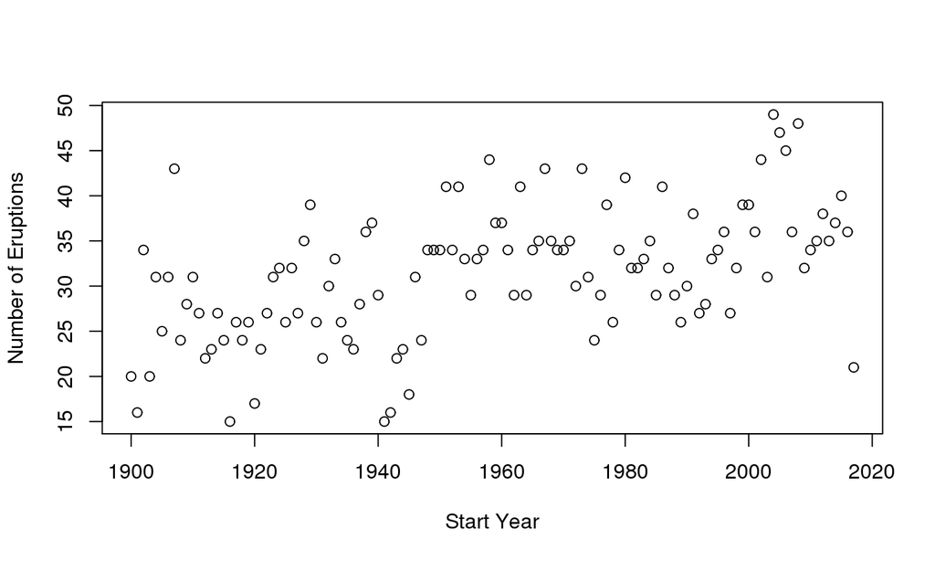

```r
plot(x = yearly$Start_Year, y = yearly$count, xlab = "Start Year", ylab = "Number of Eruptions")
```

## Data Visualization: Base R

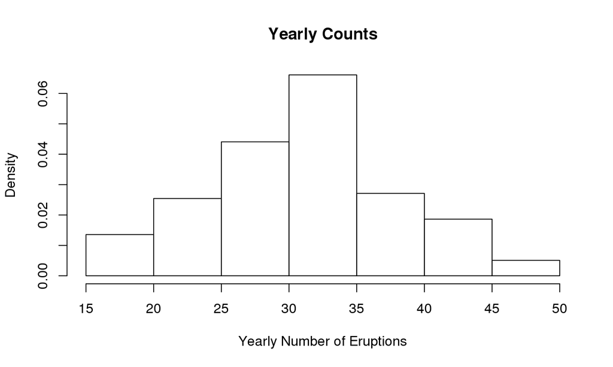

```r
hist(x = yearly$count, main = "Yearly Counts", freq = FALSE, xlab = "Yearly Number of Eruptions")
```

## Data Visualization: Tidyverse with [ggplot2](http://ggplot2.tidyverse.org/reference/)

- Based on the [*Grammar of Graphics*](https://www.amazon.com/Grammar-Graphics-Statistics-Computing/dp/0387245448)
- Big idea: Map **data** to the **aes**thetic attributes (e.g. location, size, shape, color) of **geom**etric objects (e.g. points, lines, bars).

```r
#base plot with data and aesthetics defined
#added geometric layers
#layers for labels, faceting, and other formatting
ggplot(data = DATA, aes(MAPPING)) +
  geom_OBJECT() +
  scale_*_*() + #Optional
  labs() #Optional
```

## Data Visualization: Tidyverse with [ggplot2](http://ggplot2.tidyverse.org/reference/)

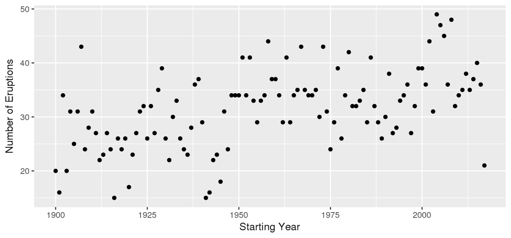

```r
library(ggplot2)
ggplot(data = yearly, aes(x = Start_Year, y = count)) + geom_point() +
    labs(x = "Starting Year", y = "Number of Eruptions")
```

## Data Visualization: Tidyverse with [ggplot2](http://ggplot2.tidyverse.org/reference/)

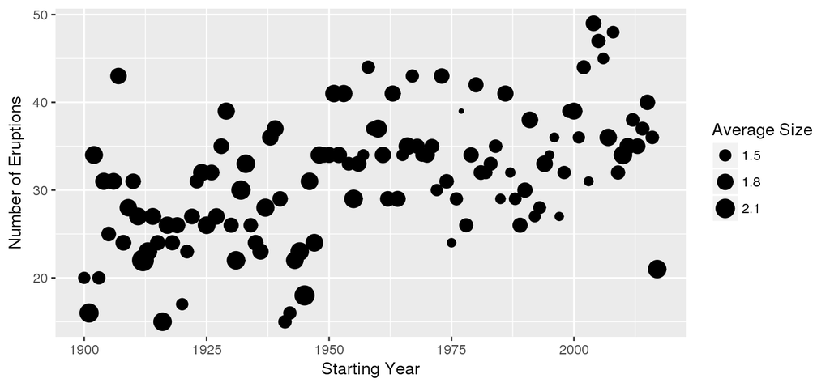

```r
ggplot(data = yearly, aes(x = Start_Year, y = count, size = avg_VEI)) +
    geom_point() + labs(x = "Starting Year", y = "Number of Eruptions",
    size = "Average Size")
```

## Data Visualization: Tidyverse with [ggplot2](http://ggplot2.tidyverse.org/reference/)

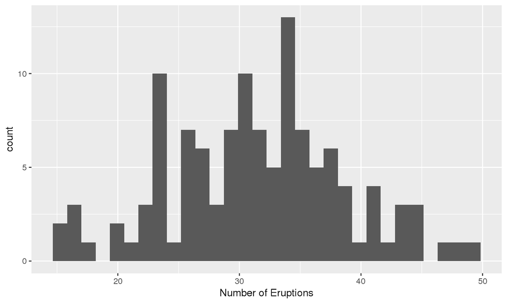

```r
ggplot(data = yearly, aes(x = count)) + geom_histogram() + labs(x = "Number of Eruptions")
```

## Data Visualization

- Both [base graphics](http://publish.illinois.edu/johnrgallagher/files/2015/10/BaseGraphicsCheatsheet.pdf) and [ggplot2](https://github.com/rstudio/cheatsheets/raw/master/data-visualization-2.1.pdf) have LOTS of features not discussed here.
- In the Tidyverse versus base R debate, graphing is a very popular point of contention.
  - [Pro base R argument](https://simplystatistics.org/2016/02/11/why-i-dont-use-ggplot2/)
  - [Pro ggplot2 argument](http://varianceexplained.org/r/teach_ggplot2_to_beginners/)
  - [Comparison of the two](https://flowingdata.com/2016/03/22/comparing-ggplot2-and-r-base-graphics/)

## Modeling

- R has a vast array of available modeling techniques.

```r
#Wrangle data
eruptions <- eruptions %>%
  filter(Start_Year>=2000) %>%
  mutate(Length = End_Year - Start_Year) %>%
  select(Eruption_Category, VEI, Length, Latitude, Longitude, Start_Year) %>%
  na.omit
```

- Disclaimer: With the missing values, censoring, and sampling biases, we should do more wrangling than this before conducting inference.

## Modeling

- Example: Linear Regression

```r
mod_lm <- lm(formula = Length ~ Start_Year + VEI * Eruption_Category, data = eruptions)
```

## Modeling

```r
summary(mod_lm)
```

```
##
## Call:
## lm(formula = Length ~ Start_Year + VEI * Eruption_Category, data = eruptions)
##
## Residuals:
##    Min     1Q Median     3Q    Max
## -1.314 -0.730 -0.504  0.184 16.059
##
## Coefficients:
##                                         Estimate Std. Error t value
## (Intercept)                              50.8902    28.2783    1.80
## Start_Year                               -0.0252     0.0141   -1.79
## VEI                                       0.1862     0.0769    2.42
## Eruption_CategoryUncertain Eruption      -0.2416     0.4008   -0.60
## VEI:Eruption_CategoryUncertain Eruption  -0.2803     0.3553   -0.79
##                                         Pr(>|t|)
## (Intercept)                                0.072 .
## Start_Year                                 0.074 .
## VEI                                        0.016 *
## Eruption_CategoryUncertain Eruption        0.547
## VEI:Eruption_CategoryUncertain Eruption    0.430
## ---
## Signif. codes:  0 '***' 0.001 '**' 0.01 '*' 0.05 '.' 0.1 ' ' 1
##
## Residual standard error: 1.8 on 684 degrees of freedom
## Multiple R-squared:  0.0204, Adjusted R-squared:  0.0147
## F-statistic: 3.56 on 4 and 684 DF,  p-value: 0.00696
```

## Modeling

[output not shown]

## Modeling

```r
# Tidy output
library(broom)
tidy(mod_lm)
```

```
##                                      term estimate std.error statistic
## 1                             (Intercept)   50.890    28.278      1.80
## 2                              Start_Year   -0.025     0.014     -1.79
## 3                                     VEI    0.186     0.077      2.42
## 4     Eruption_CategoryUncertain Eruption   -0.242     0.401     -0.60
## 5 VEI:Eruption_CategoryUncertain Eruption   -0.280     0.355     -0.79
##   p.value
## 1   0.072
## 2   0.074
## 3   0.016
## 4   0.547
## 5   0.430
```

## Modeling

```r
# Tidy output
glance(mod_lm)
```

```
##   r.squared adj.r.squared sigma statistic p.value df logLik  AIC  BIC
## 1      0.02         0.015   1.8       3.6   0.007  5  -1371 2753 2780
##   deviance df.residual
## 1     2156         684
```

## Modeling

```r
class(tidy(mod_lm))
```

```
## [1] "data.frame"
```

```r
class(summary(mod_lm))
```

```
## [1] "summary.lm"
```

- From help file of *summary()*:

> "summary is a generic function used to produce result summaries of the results of various model fitting functions. The function invokes particular methods which depend on the class of the first argument."

## Modeling

- Example: Generalized Linear Models

```r
mod_glm <- glm(formula = as.factor(Eruption_Category) ~ Start_Year + poly(x = VEI,
    degree = 2), family = "binomial", data = eruptions)
```

## Modeling

- Example: Generalized Linear Models

```r
tidy(mod_glm)
```

```
##                         term estimate std.error statistic p.value
## 1                (Intercept)  190.933    66.952      2.85 0.00435
## 2                 Start_Year   -0.097     0.033     -2.90 0.00377
## 3 poly(x = VEI, degree = 2)1  -36.000    10.225     -3.52 0.00043
## 4 poly(x = VEI, degree = 2)2   -5.301     7.746     -0.68 0.49380
```

## Modeling

- Example: ANOVA Models

```r
mod_aov <- aov(Length ~ Eruption_Category, data = eruptions)
tidy(mod_aov)
```

```
##                term  df sumsq meansq statistic p.value
## 1 Eruption_Category   1    16   15.6       4.9   0.027
## 2         Residuals 687  2185    3.2        NA      NA
```

## Predictive Modeling with [caret](https://topepo.github.io/caret/index.html)

- Classification and Regression Training
  - Data splitting (train/test datasets)
  - Modeling
  - Tuning parameters
  - Variable Importance
- Key idea: Common structure for building and comparing predictive models.
  - Allows for easy comparisons across different types of models.
- Showcased in [*Applied Predictive Modeling*](http://appliedpredictivemodeling.com/) by Max Kuhn and Kjell Johnson.

## Predictive Modeling with [caret](https://topepo.github.io/caret/index.html)

- Example: [Elastic-Net Regression](https://web.stanford.edu/~hastie/glmnet/glmnet_alpha.html)
- Model:

\[ \begin{aligned} y_i &= \beta_o + \beta_1 x_{i1} + \beta_2 x_{i2} + \ldots + \beta_p x_{ip} + \epsilon_i \\ &=\boldsymbol{x}_i^T \boldsymbol{\beta} + \epsilon_i \nonumber \end{aligned} \]

- Criteria for Coefficients:

\[ \boldsymbol{\widehat{\beta}} = \underset{\boldsymbol{\beta}}{\arg\min} \left\{ \sum_{i \in s} (y_i - \boldsymbol{x}_i^T \boldsymbol{\beta})^2 + \lambda \left[ \alpha \sum_{j=1}^p \left|\beta_j\right| + (1-\alpha) \sum_{j=1}^p \beta_j^2\right] \right\} \]

## Predictive Modeling with [caret](https://topepo.github.io/caret/index.html)

```r
library(caret)
# Set-up grid of possible lambda and alpha values
lam <- 10^seq(1, -2, length.out = 50)
alpha <- 0:10/10
grd <- expand.grid(lambda = lam, alpha = alpha)

# Set-up CV options
cv_opts <- trainControl(method = "CV", number = 10)

# Train the model for each grid point
cvfits <- train(Length ~ ., data = eruptions, method = "glmnet", tuneGrid = grd,
    trControl = cv_opts, standardize = TRUE)
```

## Predictive Modeling with [caret](https://topepo.github.io/caret/index.html)

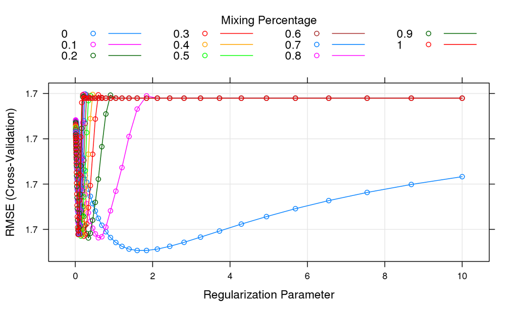

```r
plot(cvfits)
```

```r
# Optimal parameters
cvfits$bestTune
```

```
##    alpha lambda
## 37     0    1.6
```

## Predictive Modeling with [caret](https://topepo.github.io/caret/index.html)

```r
# Non-zero coefficients
bestfit <- cvfits$finalModel
coef(bestfit, s = cvfits$bestTune$lambda)
```

```
## 6 x 1 sparse Matrix of class "dgCMatrix"
##                                            1
## (Intercept)                         26.49935
## Eruption_CategoryUncertain Eruption -0.26465
## VEI                                  0.10055
## Latitude                            -0.00105
## Longitude                           -0.00019
## Start_Year                          -0.01294
```

## Report Generation via R Markdown

- Documents that weave together narrative and R code/output.
- Can create [reports](http://rmarkdown.rstudio.com/), [presentations](http://rmarkdown.rstudio.com/ioslides_presentation_format.html), [journal articles](https://github.com/rstudio/rticles), and even [books](https://bookdown.org/).
  - This presentation was made with R Markdown.
- Output formats: HTML, pdf, Word.
- Let's see how to start a new R Markdown document.

## Topics We Didn't Get to Today

- [*for* loops, *while* loops](https://www.datacamp.com/community/tutorials/tutorial-on-loops-in-r), [*ifelse*](https://www.rdocumentation.org/packages/base/versions/3.4.1/topics/ifelse)
- The family of [*apply* functions](https://www.datacamp.com/community/tutorials/r-tutorial-apply-family)
- Many of the basic functions:

```r
sd(eruptions$VEI)
```

```
## [1] 0.93
```

```r
table(eruptions$Eruption_Category)
```

```
##
## Confirmed Eruption Uncertain Eruption
##                637                 52
```

## Topics We Didn't Get to Today

- Hypothesis tests: *t.test*

```r
t.test(VEI ~ Eruption_Category, data = eruptions)
```

```
## VEI ~ Eruption_Category
```

```
##
##  Welch Two Sample t-test
##
## data:  VEI by Eruption_Category
## t = 8, df = 70, p-value = 6e-12
## alternative hypothesis: true difference in means is not equal to 0
## 95 percent confidence interval:
##  0.68 1.11
## sample estimates:
## mean in group Confirmed Eruption mean in group Uncertain Eruption
##                             1.68                             0.79
```

## Topics We Didn't Get to Today

- Generating random observations:

```r
rnorm(n = 3, mean = 5, sd = 1)
```

```
## [1] 6.0 5.9 4.2
```

```r
runif(n = 6, min = 0, max = 1)
```

```
## [1] 0.88 0.62 0.41 0.45 0.90 0.78
```

- Merging files
  - Base r [*merge*](https://www.rdocumentation.org/packages/base/versions/3.4.1/topics/merge)
  - dplyr [*joins*](https://cran.r-project.org/web/packages/dplyr/vignettes/two-table.html)
- Writing [functions](http://adv-r.had.co.nz/Functions.html) and [R packages](http://r-pkgs.had.co.nz/)

## Resources

- [R FAQ](https://cran.r-project.org/doc/FAQ/R-FAQ.html)
- [DataCamp](https://www.datacamp.com/)
- RStudio:
  - [CheatSheets](https://www.rstudio.com/resources/cheatsheets/)
  - [Online Learning](https://www.rstudio.com/online-learning/)
  - [Webinars](https://www.rstudio.com/resources/webinars/)
- Join a local user group:
  - [R user groups](https://jumpingrivers.github.io/meetingsR/r-user-groups.html)
  - [R Ladies](https://rladies.org/)

## Announcement and Questions

- If you want to learn more about building statistical/machine learning models in R, consider attending my short course, [*Statistical Learning Methods in R*](http://ww2.amstat.org/meetings/csp/2018/onlineprogram/index.cfm?SessionTypeID=147), on February 15, 2018 at the [Conference on the Statistical Practice](http://ww2.amstat.org/meetings/csp/2018/) in [Portland, OR](http://www.washingtonpost.com/sf/style/2015/06/30/the-search-for-americas-best-food-cities-portland-ore/).
- Let's *put on the breaks* and take time for questions.
  - If you have a question, type it into the Question Box.